# Capstone Project Milestone Report

Jatin Chawda

3/23/2020

# Introduction

The goal of the Data Science Capstone Project is to use the skills acquired in the specialization in creating an application based on a predictive model for text.

Given a word or phrase as input, the application will try to predict the next word. The predictive model will be trained using a corpus, a collection of written texts, called the HC Corpora which has been filtered by language.

We will create a predictive text model using a large text corpus as training data, in order to be able to predict subsequent words given some text. This will eventually be built as a Shiny application.

Review criteria:

1. Does the link lead to an HTML page describing the exploratory analysis of the training data set?
2. Has the data scientist done basic summaries of the three files? Word counts, line counts and basic data tables?
3. Has the data scientist made basic plots, such as histograms to illustrate features of the data?
4. Was the report written in a brief, concise style, in a way that a non-data scientist manager could appreciate?

## Preparing the environment

## Downloading the Data

The dataset is downloadable in zipped file via [here](https://d396qusza40orc.cloudfront.net/dsscapstone/dataset/Coursera-SwiftKey.zip).

```r
if (!file.exists("Coursera-SwiftKey.zip")) {
   download.file("https://d396qusza40orc.cloudfront.net/dsscapstone/dataset/Coursera-SwiftKey.zip","Coursera-SwiftKey.zip")
   unzip("Coursera-SwiftKey.zip")
}
download.file("http://www.cs.cmu.edu/~biglou/resources/bad-words.txt","bad-words.txt")
getwd()
```

```
## [1] "C:/Users/prati/OneDrive/Documents/FinalCapstoneproject"
```

## Loading the required libraries

```r
library(stringi)
library(tm)
library(SnowballC)
library(RWeka)
library(ggplot2)
library(wordcloud)
```

## Loading the data

```r
twitter.url <- "final/en_US/en_US.twitter.txt"
blog.url <- "final/en_US/en_US.blogs.txt"
news.url <- "final/en_US/en_US.news.txt"
twitter <- readLines(twitter.url, skipNul = TRUE, encoding = "UTF-8")
blog <- readLines(blog.url, skipNul = TRUE, encoding = "UTF-8")
news.file <- file(news.url,"rb")
news <- readLines(news.file, skipNul = TRUE, encoding = "UTF-8")
close(news.file)
```

##Basic Summary of Data

```r
create_summary_table <- function(twitter,blog,news){
  stats <- data.frame(source = c("twitter","blog","news"),
            arraySizeMB = c(object.size(twitter)/1024^2,object.size(blog)/1024^2,object.size(news)/1024^2),
            fileSizeMB = c(file.info(twitter.url)$size/1024^2,file.info(blog.url)$size/1024^2,file.info(news.url)$size/1024^2),
            lineCount = c(length(twitter),length(blog),length(news)),
            wordCount = c(sum(stri_count_words(twitter)),sum(stri_count_words(blog)),sum(stri_count_words(news))),
            charCount = c(stri_stats_general(twitter)[3],stri_stats_general(blog)[3],stri_stats_general(news)[3])
  )
  print(stats)
}
create_summary_table(twitter,blog,news)
```

```
##    source arraySizeMB fileSizeMB lineCount wordCount charCount
## 1 twitter    318.9897   159.3641   2360148  30093413 162096241
## 2    blog    255.3545   200.4242    899288  37546239 206824382
## 3    news    257.3404   196.2775   1010242  34762395 203223154
```

## Sampling the data

In order to enable faster data processing, a data sample from all three sources was generated, therefore there are 10,000 rows of each dataset sampled and combined into a single dataset.

```r
set.seed(12345)
sampleData <- c(sample(twitter,10000),
                sample(blog,10000),
                sample(news,10000))
```

## Cleaning the Data

Cleaning the data includes:

1. Cleaning all non ASCII characters
2. Transforming all data to lower case
3. Deleting all English stopwords and any stray letters left my the non-ASCII removal
4. Removing Punctuation
5. Removing Numbers
6. Removing Profanities
7. Removing all stray letters left by the last two calls
8. Striping all extra whitespace

```r
corpus <- VCorpus(VectorSource(sampleData))
toSpace <- content_transformer(function(x, pattern) {return (gsub(pattern," ",x))})
# Cleaning all non ASCII characters
corpus <- tm_map(corpus,toSpace,"[^[:graph:]]")

# Transforming all data to lower case
corpus <- tm_map(corpus,content_transformer(tolower))

# Deleting all English stopwords and any stray letters left my the non-ASCII removal
corpus <- tm_map(corpus,removeWords,c(stopwords("english"),letters))


# Removing Punctuation
corpus <- tm_map(corpus,removePunctuation)

# Removing Numbers
corpus <- tm_map(corpus,removeNumbers)

# Removing Profanities
profanities = readLines('bad-words.txt')

corpus <- tm_map(corpus, removeWords, profanities)

# Removing all stray letters left by the last two calls
corpus <- tm_map(corpus,removeWords,letters)

# Striping all extra whitespace
corpus <- tm_map(corpus,stripWhitespace)
```

## Tokenize sample into Unigrams, Bigrams and Trigrams

We use Tokenization to break sentences and phrases in to pairs of words or n-grams. Essentially we are breaking down units of words or tokens, hence the term tokenization.

We will use RWeka package for tokenization

```r
#Creating a unigram DTM
unigramTokenizer <- function(x) {NGramTokenizer(x, Weka_control(min = 1, max = 1))}
unigrams <- DocumentTermMatrix(corpus, control = list(tokenize = unigramTokenizer))
#Creating a bigram DTM
BigramTokenizer <- function(x) {NGramTokenizer(x, Weka_control(min = 2, max = 2))}
bigrams <- DocumentTermMatrix(corpus, control = list(tokenize = BigramTokenizer))
#Creating a trigram DTM
TrigramTokenizer <- function(x) {NGramTokenizer(x, Weka_control(min = 3, max = 3))}
trigrams <- DocumentTermMatrix(corpus, control = list(tokenize = TrigramTokenizer))
```

```r
freqTerms <- findFreqTerms(unigrams,lowfreq = 1000)
unigrams_frequency <- sort(colSums(as.matrix(unigrams[,freqTerms])),decreasing = TRUE)
unigrams_freq_df <- data.frame(word = names(unigrams_frequency), frequency = unigrams_frequency)


freqTerms <- findFreqTerms(bigrams,lowfreq = 50)
bigrams_frequency <- sort(colSums(as.matrix(bigrams[,freqTerms])),decreasing = TRUE)
bigrams_freq_df <- data.frame(word = names(bigrams_frequency), frequency = bigrams_frequency)

freqTerms <- findFreqTerms(trigrams,lowfreq = 10)
trigrams_frequency <- sort(colSums(as.matrix(trigrams[,freqTerms])),decreasing = TRUE)
trigrams_freq_df <- data.frame(word = names(trigrams_frequency), frequency = trigrams_frequency)
```

## Data Plotting

Below the the graphs for the most common ngrams can be seen.

## Unigrams

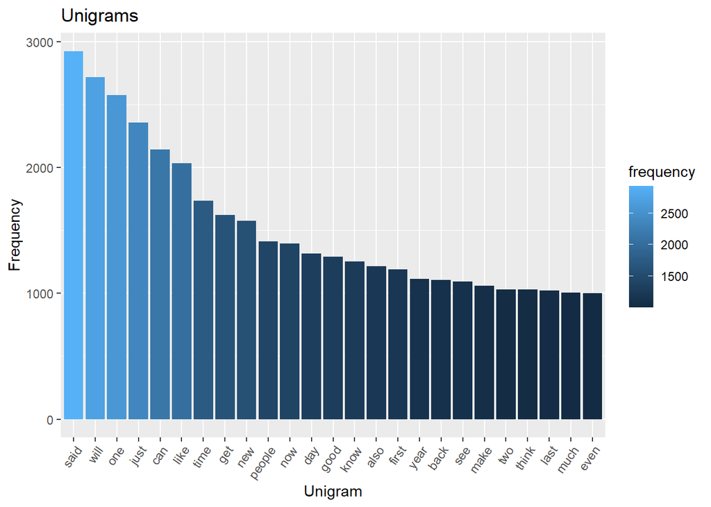

```r
g <- ggplot(unigrams_freq_df,aes(x=reorder(word,-frequency),y=frequency))+
     geom_bar(stat="identity",aes(fill=frequency)) +
     xlab("Unigram") +
     ylab("Frequency") +
     labs(title="Unigrams") +                                                        theme(axis.text.x=element_text(angle=55, hjust=1))
g
```

## Bigrams

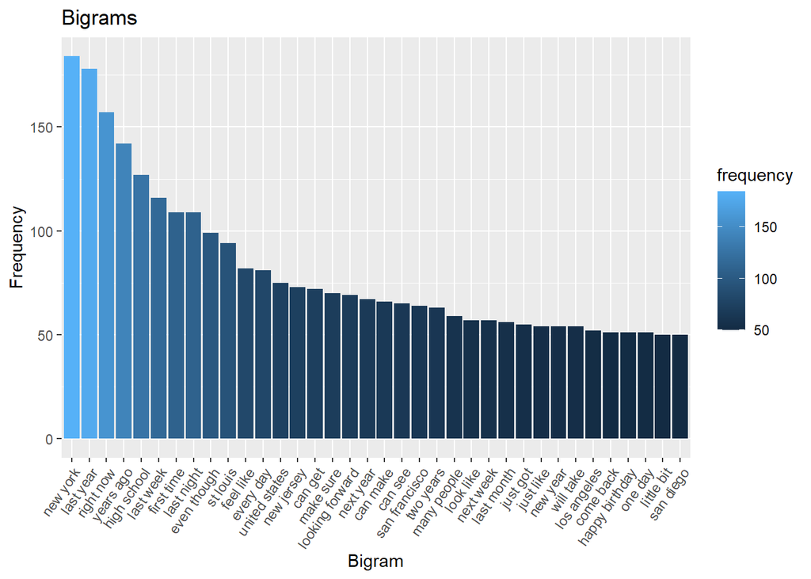

```r
g <- ggplot(bigrams_freq_df,aes(x=reorder(word,-frequency),y=frequency))+
     geom_bar(stat="identity",aes(fill=frequency)) +
     xlab("Bigram") +
     ylab("Frequency") +
     labs(title="Bigrams") +                                                         theme(axis.text.x=element_text(angle=55, hjust=1))
g
```

## Trigrams

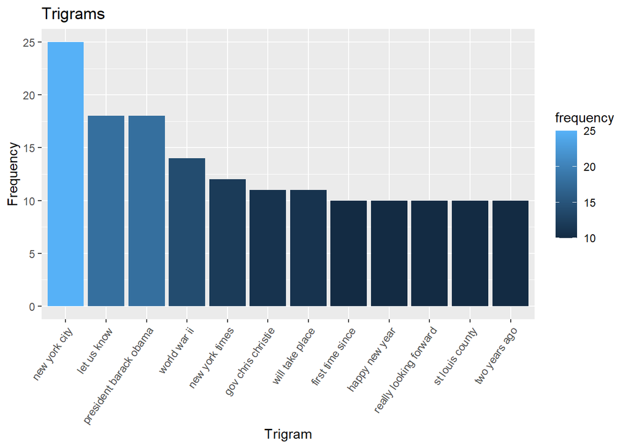

```r
g <- ggplot(trigrams_freq_df,aes(x=reorder(word,-frequency),y=frequency))+
     geom_bar(stat="identity",aes(fill=frequency)) +
     xlab("Trigram") +
     ylab("Frequency") +
     labs(title="Trigrams") +
     theme(axis.text.x=element_text(angle=55, hjust=1))
g
```

## Plans for the prediction algorithm and Shiny app

Concluding the exploratory analysis of the data, the next steps of this project are to finalize the predictive algorithm, deploy the model as a Shiny application and also create a deck to be able to present the final result.